# Week 8: Network Data II - spatial and dynamic networks

161.307 Reproducible Visualisation for Statistics

School of Mathematical and Computational Sciences, Massey University

14 Sep 2026

## This week

- Lecture 1: Networks are spatial now
- Lecture 2: Epidemics on networks
- Tutorials: networks on maps, networks over time, and a capstone that brings together simulation (Week 5), uncertainty (Week 6), and network visualisation (Week 7) in one multi-panel figure

## This week

Portfolio 7 does not require you to build maps or wrestle with coordinate systems. That’s tutorial/capstone territory. It asks you to simulate ER/BA/WS networks (Week 7), run a real S/I/R process on each (Week 8), and see whether structure changes how an epidemic behaves.

References:

- Bjørnstad (2018) *Epidemics: Models and Data using R*
- Lovelace et al. (2018) *Geographic Data Science with R*
- Moraga (2020) *Geospatial Health Data*

# Lecture 1: Spatial networks

## Networks embedded in space

- Week 7: node position came from a *layout algorithm*. It is chosen for visual clarity, meaning nothing on its own
- Now: node position comes from **real coordinates** (latitude/ longitude), so position itself carries information
- Edges get a geographic story: flights between cities, contacts between regions, migration between countries

## From layout to coordinates

```r
cities <- data.frame(
  name = c("Auckland", "Wellington", "Christchurch", "Hamilton", "Dunedin"),
  lon  = c(174.76, 174.78, 172.64, 175.28, 170.50),
  lat  = c(-36.85, -41.29, -43.53, -37.78, -45.87)
)
edges <- data.frame(
  from = c("Auckland","Auckland","Wellington","Wellington","Hamilton"),
  to   = c("Wellington","Hamilton","Christchurch","Dunedin","Christchurch")
)

g <- tbl_graph(nodes = cities, edges = edges, directed = FALSE)

ggraph(g, layout = "manual", x = cities$lon, y = cities$lat) +
  geom_edge_link(alpha = 0.6) +
  geom_node_point(size = 3, colour = "darkred") +
  geom_node_text(aes(label = name), repel = TRUE, size = 3) +
  coord_fixed(ratio = 1.3) +
  theme_minimal() +
  labs(title = "A spatial network, no basemap yet",
       x = "Longitude", y = "Latitude")
```

## From layout (networks) to coordinates (maps)

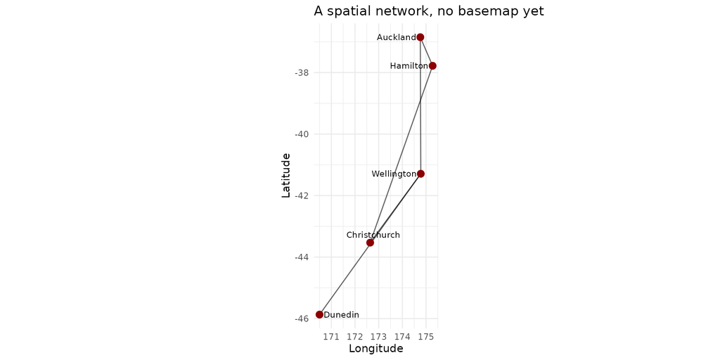

- Change from Week 7: `x`/`y` no longer a layout algorithm’s choice but `lon`/`lat`
- layout = “manual” with real coordinates turns `ggraph` into a geographic plot

## Layering a network on a basemap

- A **choropleth** shades regions (councils, countries) by a value: `geom_sf(data = regions, aes(fill = value))`
- `ggplot2` stacks layers in the order you add them, so drawing the choropleth first, then the network on top, “just works”…as long as every layer shares the same coordinate system

```r
set.seed(42)
cities_sf <- st_as_sf(cities, coords = c("lon","lat"), crs = 4326)
edge_lines <- lapply(seq_len(nrow(edges)), function(i) {
  from_pt <- as.numeric(cities[cities$name == edges$from[i], c("lon","lat")])
  to_pt   <- as.numeric(cities[cities$name == edges$to[i],   c("lon","lat")])
  st_linestring(rbind(from_pt, to_pt))
})
edges_sf <- st_sf(edges, geometry = st_sfc(edge_lines, crs = 4326))

# stand-in "regions": a buffer disc around each city. Swap for a real
# regional-council shapefile in practice. The plotting code is identical
regions_sf <- st_buffer(cities_sf, dist = 50000) |> # careful dist in m!!
  mutate(cases = round(runif(n(), min = 20, max = 200))) # random to create data

regions_sf$cases

ggplot() +
  geom_sf(data = regions_sf, aes(fill = cases), alpha = 0.7) +
  geom_sf(data = edges_sf, colour = "black", linewidth = 1) +
  geom_sf(data = cities_sf, colour = "darkred", size = 4) +
  scale_fill_viridis_c(option = "magma", name = "Cases") +
  theme_minimal() +
  labs(title = "Choropleth + network, one coordinate system")
```

## Layering a network on a basemap

```
[1] 146 120  45  71 120
```

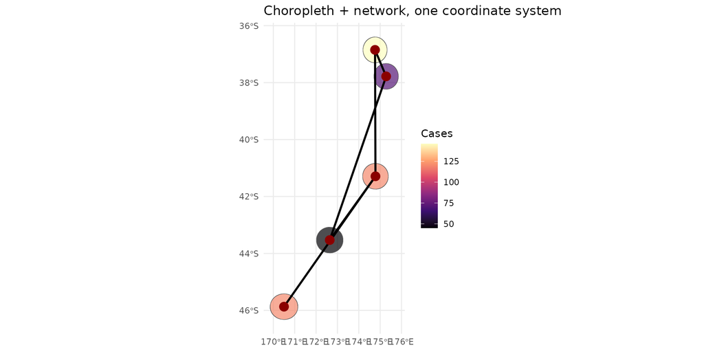

## The one technical point that matters: CRS

- A **Coordinate Reference System (CRS)** says how (lon, lat) or (x, y) numbers map onto the actual Earth
- Two datasets can both look like “just numbers” and still disagree: one in plain lon/lat, one in a projected metres-based system (e.g. NZTM, `EPSG:2193`)
- Almost every spatial-network bug is a silent CRS mismatch (I encountered). The fix is one line: transform everything to a common CRS before plotting

```r
regions_nztm <- st_transform(regions_sf, 2193)   # metres-based (NZTM)
st_crs(cities_sf)$input        # "EPSG:4326" -- lon/lat, doesn't match!
```

```
[1] "EPSG:4326"
```

```r
cities_nztm <- st_transform(cities_sf, st_crs(regions_nztm))
st_crs(cities_nztm)$input      # now matches regions_nztm
```

```
[1] "EPSG:2193"
```

Not more `sf` machinery than this needed for the course.

## Straight lines lie…a little

- A straight line between two (lon, lat) points is not the shortest path on a sphere - the shortest path curves
- At NZ-regional scale this barely matters; at global scale, use an arc rather than a straight segment

```r
airports <- data.frame(
  name = c("Auckland", "Sydney", "Singapore", "London", "Los Angeles"),
  lon  = c(174.76, 151.21, 103.82, -0.13, -118.24),
  lat  = c(-36.85, -33.87, 1.35, 51.51, 34.05),
  case_count = c(12, 3, 8, 5, 2)
)
flight_edges <- data.frame(
  from = c("Auckland", "Auckland", "Singapore", "London"),
  to   = c("Sydney", "Singapore", "London", "Los Angeles"),
  n_imported_cases = c(4, 9, 3, 1)
)
flight_graph <- tbl_graph(nodes = airports, edges = flight_edges, directed = TRUE)

ggraph(flight_graph, layout = "manual", x = airports$lon, y = airports$lat) +
  geom_edge_arc(aes(colour = n_imported_cases), curvature = 0.2) +
  geom_node_point(aes(size = case_count)) +
  geom_node_text(aes(label = name), repel = TRUE, size = 3) +
  theme_minimal() +
  labs(title = "Imported case pathways by flight route")
```

## Straight lines lie…a little

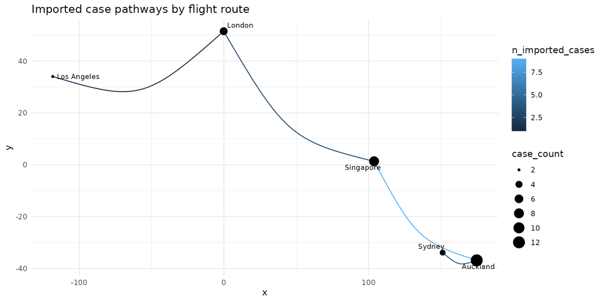

## The hairball problem, now on a map

- Real spatial networks (flight routes, commuting, migration) often have far more edges than nodes $\to$ the Week 7 hairball problem, again, this time overlaid on real geography
- Dedicated **edge-bundling** algorithms (e.g. the `edgebundle` package) group edges travelling similar paths into visual bundles, trading a little precision for a lot of clarity
- A cheap, no-extra-package approximation: draw many low-alpha curved edges (`geom_edge_fan`) so that shared “corridors” darken by overlap, while a single trip stays nearly invisible

```r
set.seed(3)
cases <- data.frame(name = paste0("case_", 1:30),
                     lon = runif(30, 172, 176), lat = runif(30, -41, -36))
contact_edges <- data.frame(
  from = sample(cases$name, 60, replace = TRUE),
  to   = sample(cases$name, 60, replace = TRUE)
) |> filter(from != to)
g_contacts <- tbl_graph(nodes = cases, edges = contact_edges, directed = FALSE)

ggraph(g_contacts, layout = "manual", x = cases$lon, y = cases$lat) +
  geom_edge_fan(alpha = 0.15, colour = "firebrick") +
  geom_node_point(size = 2, colour = "grey30") +
  theme_void() +
  labs(title = "Overlap-as-density: a cheap stand-in for edge bundling")
```

## The hairball problem, now on a map

## Not really a problem with this density

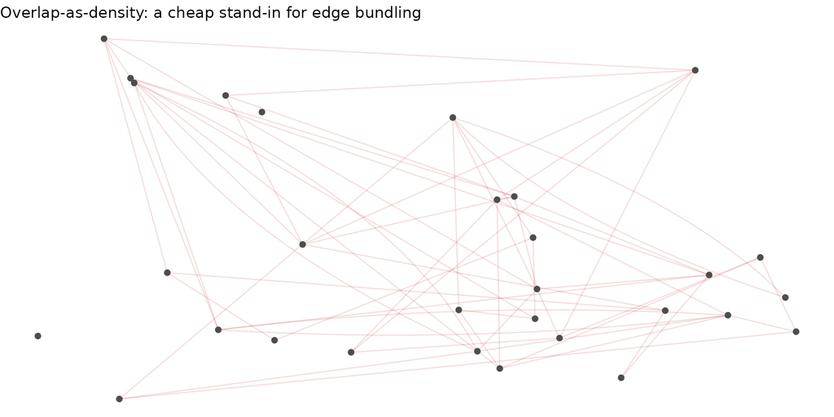

## The hairball problem, now on a map

### 60 $\to$ 200 edges

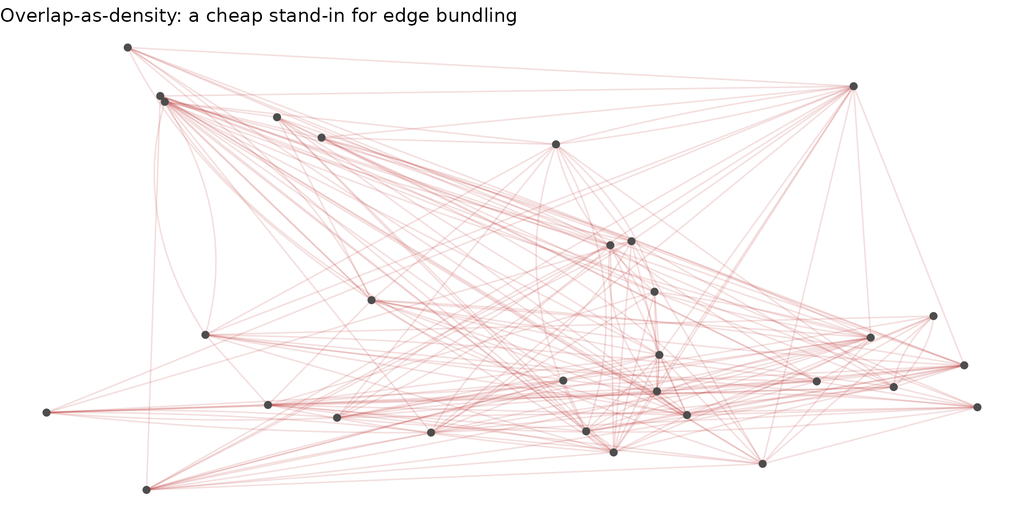

## The hairball problem, now on a map

### 60 $\to$ 200 $\to$ 500 edges

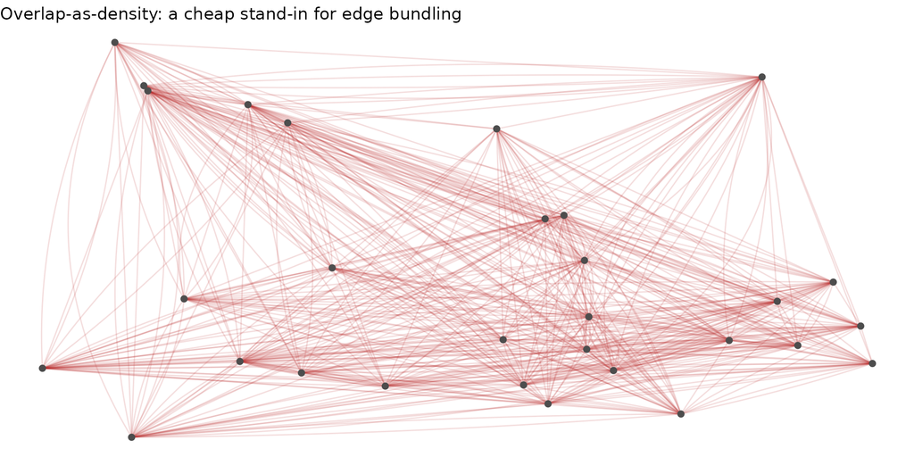

## Lecture 1: summary

- Same node-link/choropleth grammar as before; the only new idea is that position and CRS now carry real meaning
- Match every layer’s CRS before plotting. That single habit prevents almost every spatial-network bug
- Edge-bundling and geodesics are refinements for dense/global networks; nice to know

# Lecture 2: Epidemics on networks

## Recap: Week 7’s sneak peek

- Week 7 constrained a branching process (see Week 5) to a random contact network: a case could only infect its **network neighbours**$ $ the resulting growth curve looked nothing like an unconstrained branching process.
- In that example, we tracked *new cases* only. Real S/I/R models need one more ingredient: people also **recover**, and recovered people stop transmitting (but can revert to Susceptible if SIRS model)

## A closed village, 1665

Before we build the model: *why* do we build such model?

### A real outbreak to build it *for*

In September 1665 the Derbyshire village of Eyam received a parcel of cloth from London carrying plague-infected fleas. Rather than flee, the village, led by the rector, William Mompesson, sealed itself off: no one in, no one out, for over a year, to stop the disease reaching neighbouring villages. It worked, for the neighbours. For Eyam itself, 257 of roughly 350 residents died.

## Eyam: a real outbreak modelling

Because migration was ruled out by the quarantine, Eyam became one of the first outbreaks anyone tried to model mathematically (Raggett, 1982). And because the whole village was effectively sealed in together, it is a natural candidate for the simplest possible mixing assumption: **everyone can potentially contact everyone else**.

## Eyam: a real outbreak modelling

```r
eyam <- data.frame(
  day = c(0, 15, 30, 45, 60, 75, 90, 120),
  S   = c(254, 235, 201, 153, 121, 110, 97, 83),
  I   = c(7, 14, 22, 29, 20, 8, 8, 0)
)
ggplot(eyam, aes(day, I)) +
  geom_line(colour = "black") + geom_point(colour = "black", size = 2) +
  labs(title = "Eyam, June-October 1666",
       subtitle = "Infective count over time (Raggett, 1982); population = 261",
       x = "Day", y = "Number infective") +
  theme_minimal()
```

## Eyam: a real outbreak modelling

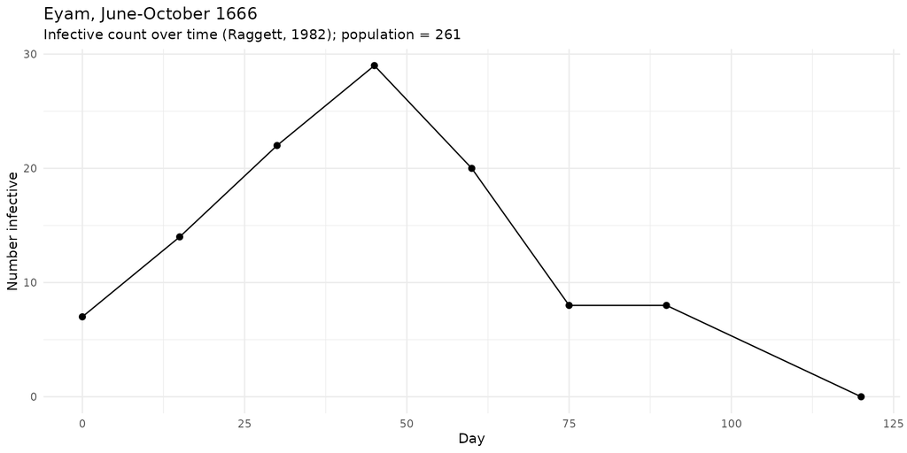

We’ll keep coming back to this real curve as we build the model.

## From branching to S/I/R: three states, one clock

Think of it as a relay race running on the network, one tick of a clock at a time:

- **S**usceptible: hasn’t caught it yet
- **I**nfected: has it, and can (i) pass it to susceptible *neighbours* with probability `beta`, per neighbour, and (ii) lose it with probability `gamma`.
- **R**ecovered: had it, is done, can’t catch or spread it again

## From branching to S/I/R: three states, one clock

### Algorithm

At each tick:

1. every `I`nfected node “flips a coin” against each `S`usceptible neighbour (`beta`);
2. every `I`nfected node also flips a coin towards `R`ecovering (`gamma`).

Everyone updates together, then the clock ticks again.

## Interpreting `beta` and `gamma`

These two numbers are not just dimmer switches:

- `gamma` is roughly **1 / (how many ticks you’re infectious for)**. Plague’s infectious period is about 11 days, so `gamma` $\approx$ 1/11 $\approx$ 0.09 per day. I.e. about a 9% chance of “recovering” (for plague, dying) on any given day one is still infected.
- `beta` is the **per-contact, per-tick chance of passing it on**. It is a property of the disease and the *type* of contact, not of the network.

## Interpreting `beta` and `gamma` on a network

Put `beta` and `gamma` together with how many neighbours a person has (`degree`) and you get a heuristics calculation for whether an outbreak takes off at all: an infected person has, on average, `degree` $\times$ `beta` chances per tick to pass it on, over roughly `1/gamma` ticks of being infectious. So the $R_0$ ratio is of interest:

$$R_0 \approx \frac{\text{degree} \times \text{beta}}{\text{gamma}}$$

## Interpreting $R_0$ for disease propagation vs extinction

- With $R_0$ above 1, cases tend to replace themselves more than once and an outbreak can grow; below 1, it tends to fizzle
- It’s a rough, averaged behaviour heuristic
- It ignores who’s already immune and how contacts overlap
- But it’s a useful sanity check before you press go on a simulation

## A worked S/I/R-on-a-network function

```r
simulate_sir <- function(g, beta, gamma, n_init = 1, n_steps = 60, seed = NULL) {
  if (!is.null(seed)) set.seed(seed)
  n <- igraph::vcount(g)
  status <- rep("S", n)
  status[sample(n, n_init)] <- "I" # patient(s) zero chosen at random
  # Output storage matrix
  out <- data.frame(day = 1:n_steps, S = NA, I = NA, R = NA)
  # Start the infection clock
  for (t in 1:n_steps) {
    infected <- which(status == "I")
    if (length(infected) == 0) { # outbreak has died out
      out[t:n_steps, c("S","I","R")] <-
        matrix(c(sum(status=="S"), 0, sum(status=="R")),
               nrow = n_steps - t + 1, ncol = 3, byrow = TRUE)
      break
    }
    new_infections <- integer(0)
    for (node in infected) {
      neighbours <- igraph::neighbors(g, node)
      susceptible_neighbours <- neighbours[status[neighbours] == "S"]
      if (length(susceptible_neighbours) > 0) {
        caught_it <- susceptible_neighbours[runif(length(susceptible_neighbours)) < beta]
        new_infections <- union(new_infections, as.integer(caught_it))
      }
    }
    recoveries <- infected[runif(length(infected)) < gamma]

    status[new_infections] <- "I"
    status[recoveries] <- "R"
    out$S[t] <- sum(status == "S")
    out$I[t] <- sum(status == "I")
    out$R[t] <- sum(status == "R")
  }
  out
}
```

## Fitting the complete graph to Eyam, by eye

If “everyone can contact everyone” is a fair assumption for a sealed village of 261 people, a complete graph can be used. With `gamma` fixed by the biology (11-day infectious period), we can nudge `beta` until the curve looks accurate enough:

```r
n <- 261
g_full <- igraph::make_full_graph(n = n)
gamma <- 1 / 11
beta <- 0.0006 # tuned by hand

sir_full <- simulate_sir(g_full, beta, gamma, n_init = 7, n_steps = 130, seed = 10)

ggplot(sir_full, aes(day, I)) +
  geom_line(linewidth = 1, colour = "firebrick") +
  geom_point(data = eyam, aes(day, I), inherit.aes = FALSE, size = 2) +
  labs(title = "Complete graph SIR vs. the real Eyam curve",
       subtitle = "Line = simulated, points = real data",
       x = "Day", y = "Number infected") +
  theme_minimal()
```

## Fitting the complete graph to Eyam, by eye

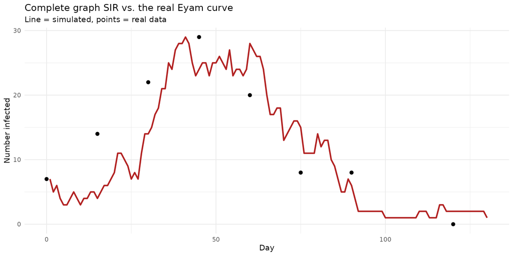

## Fitting the complete graph to Eyam, by eye

Notice that it is **not** a formal (e.g. maximum-likelihood) fit.

We “fine-tuned” `beta` until the peak height and timing looked about right. It tracks the real curve surprisingly well. That’s a point in favour of “full mixing” as a reasonable model for a village that had nowhere else to go.

Is `beta` making sense?